# Statistical challenges in single-cell RNA-seq analysis III

July 6, 2019

## Preview

1. Introduction to single-cell RNA-seq
2. Quality control and normalization
3. **Survey of downstream analysis methodology**

## Highly variable genes

- Goal: identify a set of genes with high variability attributable to biology (over and above technical variability)
- Useful for vizualization, dimension reduction, clustering, marker gene selection, etc
- Challenging without orthogonal measurement of technical variability (e.g. spikeins)
  - with spikeins: select genes with variance significantly above mean-variance trend in control genes
  - without spikeins: select genes with variance significantly above overall mean-variance trend in all endogenous genes (**assumes variance of most genes is purely technical**)

## Highly variable genes with spikeins

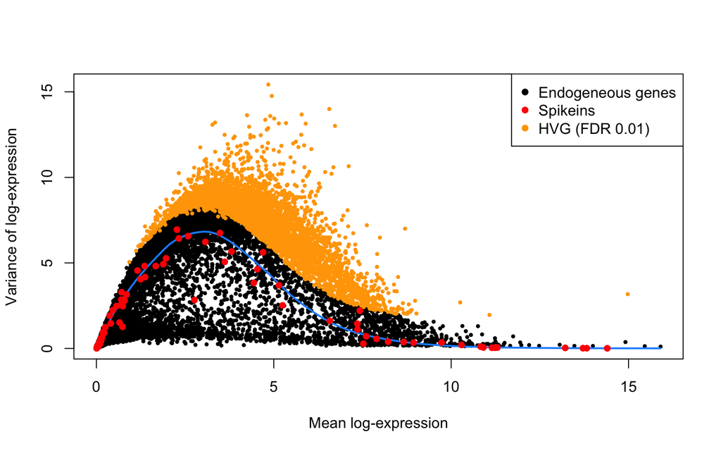

## Highly variable genes without spikeins

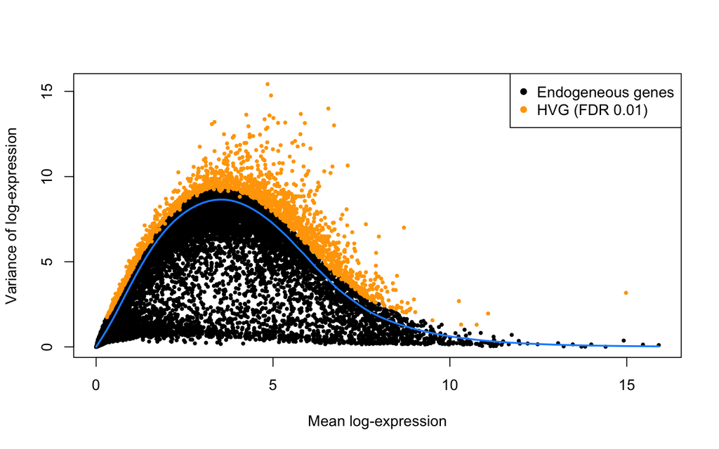

## Dimension reduction

- Useful to summarize & visualize relationships between cells in low dimensional space
- Commonly used approaches:
  - PCA (Principal Components Analysis)
  - tSNE (t-distributed Stochastic Neighbor Embedding)
  - UMAP (Uniform Manifold Approximation and Projection)
- Clustering can be carried out on reduced dimensions, but **with caution**

## PCA vs Nonlinear methods

- PCA attempts to extract the largest components of variation in the data
- Nonlinear methods such as tSNE and UMAP attempt to map points to a global coordinate system that preserves local structure
  - density & distance of points not preserved
  - may excel at visualizing rare subtypes

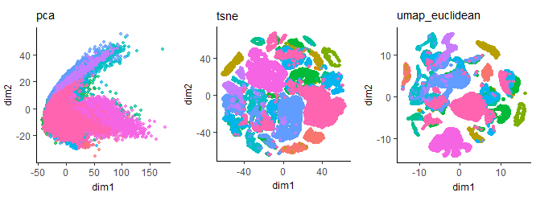

image source: http://carbonandsilicon.net/rblogging/2018/02/27/UMAP_plots

## tSNE

## Clustering

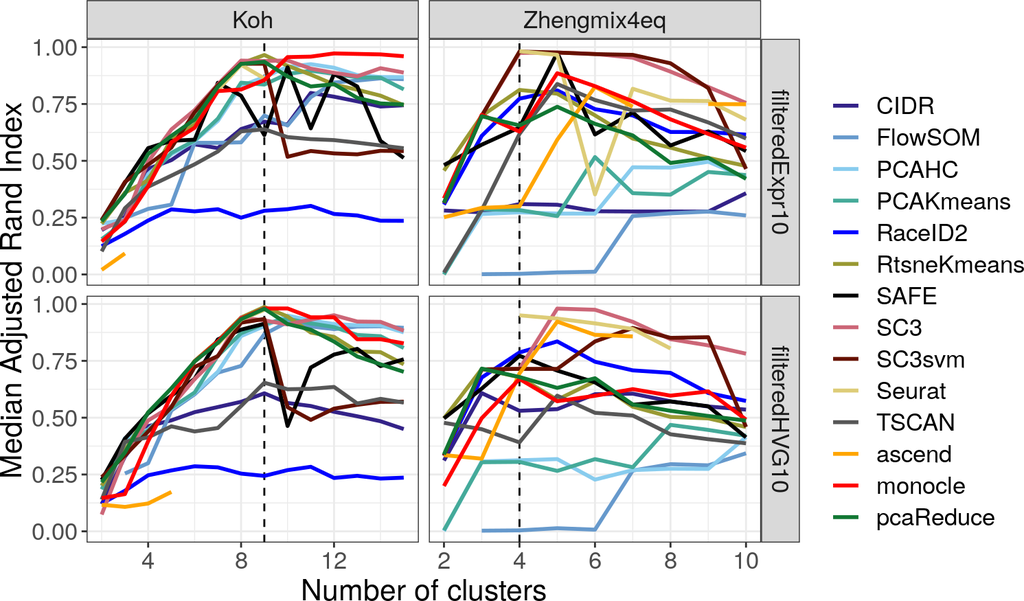

## Differential expression

## scdd

## DE after clustering

## R tools for downstream analysis

- [scater](http://bioconductor.org/packages/scater/): visualization, quality control (Bioconductor)
- [scran](http://bioconductor.org/packages/scran/): normalization, doublet detection, batch effect correction (Bioconductor)
- [SCnorm](http://bioconductor.org/packages/SCnorm/): normalization (Bioconductor)
- sctransform: normalization (CRAN)
- [DropletUtils](http://bioconductor.org/packages/DropletUtils/): removal of empty droplets (Bioconductor)
- [Seurat](https://satijalab.org/seurat/): normalization (CRAN)

[figure not shown]

[figure not shown]

[figure not shown]

## There are many more tools I didn’t mention…

## Growing number of computational tools

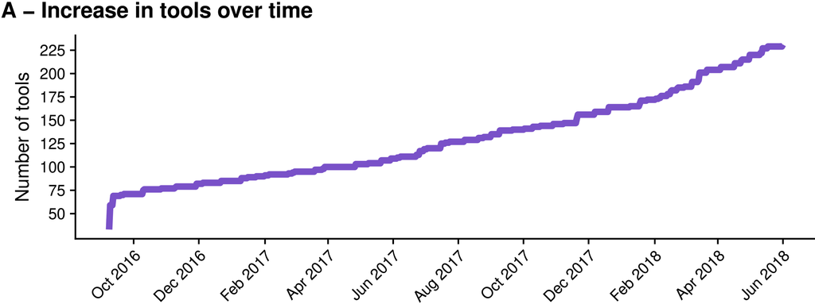

Zappia, Phipson & Oshlack 2018 (https://doi.org/10.1371/journal.pcbi.1006245)

## Curated list of tools from Sean

[figure not shown]